# Matriks Itu Mudah Kawann…

Yukk, belajar bersama  
A. TRANPOSE MATRIKS  
Tranpose Matriks A adalah matriks baru yang diperoleh dengan cara menukar elemen baris menjadi elemen kolom atau sebaliknya.  
Contoh:

[figure not shown]

B. OPERASI MATRIKS  
a. Penjumlahan dan Pengurangan  
Dua buah matriks dapat dijumlahkan atau dikurangkan bila ordonya sama dan elemen yang posisinya seletak dapat dijumlahkan atau dikurangi.  
Contoh:

[figure not shown]

b. Perkalian Matriks  
1.) Perkalian dengan bilangan konstanta dapat dilakukan dengan mengalikan ke setiap elemen matriks tersebut.

[figure not shown]

2.) Perkalian matriks dengan matriks, syaratnya kolom matriks A sama dengan baris matriks B.

[figure not shown]

C. DETERMINAN MATRIKS  
a. Determinan Matriks Berordo 2x2  
Apabila matriksnya berbentuk 2 x 2, maka rumus untuk mencari determinan ialah :

[figure not shown]

Nilai determinan A di simbolkan dengan | A | , cara menghitung nilai determinan A dapat di lihat seperti cara yang di bawah ini :

[figure not shown]

b. Determinan Matriks Berordo 3x3  
Matriks berordo 3 ialah matriks bujur sangkar dengan banyaknya kolom dan baris sama dengan tiga.

[figure not shown]

c. Sifat-Sifat Determinan Matriks

[figure not shown]

D. INVERS MATRIKS  
Dua matriks saling invers terjadi jika A dan B adalah matriks persegi yang berordo sama dan memiliki syarat:  
A.B = B.A = I, dimana I = matriks identitas, maka dapat dikatakan A adalah invers B dan B adalah invers A.  
Invers A dinotasikan dengan A^-1 (A pangkat minus 1), sedangkan invers B dinotasikan dengan B^-1 (B pangkat minus 1).  
1. Invers Matriks Berordo 2x2  
Contoh,

[figure not shown]

, maka

[figure not shown]

2. Invers Matriks Berordo 3x3  
Untuk mencari invers matriks ordo 3x3, perlu pemahama matriks-matriks berikut:  
1. Matriks Kofaktor  
2. Adjoin  
3. Nilai Elemen  
4. Rumus Invers Matriks Berordo 3x3  
Keterangan:  
- Matriks Kofaktor adalah matriks yang unsurnya diganti dengan nilai determinan yang unsurnya tidak sebaris dan tidak sekolom dengan unsur asal. Untuk tandanya digunakan tanda positif negatif saling bergantian.  
- Adjoin adalah matriks kofaktor yang di Transposkan ( baris jadi kolom , kolom jadi baris ).  
Contoh:

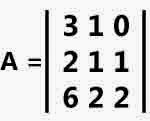

Langkah pertama maka kita harus mencari kofaktor dari A , dengan cara sbb:

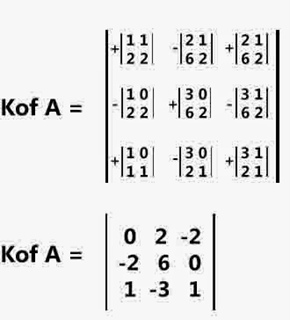

Langkah kedua, Setelah hasil dari Kofaktor A ditemukan , maka kita mencari ADJOIN nya =

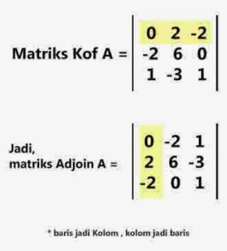

Langkah ketiga , Mencari nilai determinan A :

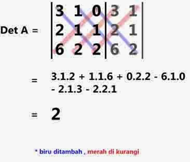

Langkah terakhir adalah mencari invers matriks A dengan rumus :  
Invers Matriks nxn = 1 / nilai determinan . Matriks Adjoinnya  
jadi matriks invers A adalah =

[figure not shown]

3. Sifat-Sifat Invers Matriks

[figure not shown]